# Tuto_importation_de_donnees

Author

Christopher

# Importation de données

Sur cette page web, je vais vous montrer comment importer des données en utilisant du code R, afin d’éviter les erreurs d’importation et de ne pas avoir à réimporter les fichiers à chaque redémarrage de R (particulièrement pratique lors des examens ou des stages).

## Première étape (où est mon fichier)

Ouvre Rstudio, crée un nouveau script. Nous allons utiliser une des fonctions de R pour l’importation de données qui ne nécessite aucun package `read.table()`.

Regarde ensuite où ton fichier à importer est placé et copie-colle son emplacement

[figure not shown]

Effectue un clic gauche puis un clic droit et clic sur “Copier en tant que chemin d’accès”.

Résultat : “C: \ Users \ chris \ Documents \ M2\TUTORAT\hta.txt” tu obtiens le chemin d’accès pour que R retrouve l’emplacement de ton ficher.

Ici, l’extension `.txt` indique qu’il s’agit d’un fichier *texte*.

## READ.TABLE()

Utilise la fonction `read.table()`, cette fonction à plusieurs paramètres pour l’importation nous allons nous concentrer sur les 4 principales.

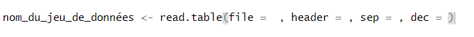

Ainsi on passe de : “C:\ Users\ chris\ Documents\ M2\TUTORAT\hta.txt”

à “C:\\Users\\ chris\\ Documents\\ M2\\ TUTORAT\\ hta.txt”

et met le dans le `file`

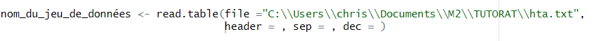

Le paramètre `header` indique à R si la première ligne du fichier doit être considérée comme une ligne d’en-têtes, c’est-à-dire les noms des colonnes du jeu de données.

Pour dire oui/non en R on utilise TRUE/FALSE.

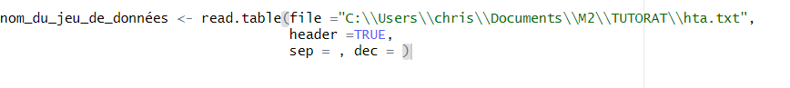

Le paramètre `sep` permet d’indiquer à R quel caractère sépare les différentes colonnes dans ton fichier de données.

| Format du ficher | sep = | Commentaires |
| --- | --- | --- |
| CSV | `","` | Utilisé quand les colonnes sont séparées par des **virgules** |
| Excel (xls) | `";"` | Utilisé quand les colonnes sont séparées par des **points-virgules** |
| texte | `"\t"` ou `""` | Les colonnes sont séparées par une **tabulation (\t) ou** Les valeurs sont séparées par un **espace (““)** |

Dans notre exemple c’est un fichier texte cependant nous ne savons pas si c’est un séparateur tabulation ou espace. Pour cela, nous devons ouvrir le fichier de données.

Passe ta souris sur le texte : si la sélection devient bleue jusqu’à la variable suivante, cela signifie qu’il y a une tabulation.

Dans le cas contraire, si la sélection s’arrête entre les mots, ce sont simplement des espaces.

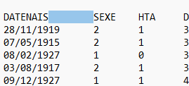

Ici c’est bien une tabulation donc

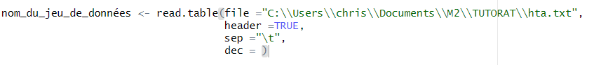

Le paramètre `dec` permet d’indiquer à R quel symbole est utilisé pour séparer les décimales dans ton fichier de données.

Cela dépend souvent du pays d’où vient le ficher de données. Souvent les USA/UK ils utilisent `.` pour séparer les décimales alors que en France on utilise les `,`

Le moyen le plus simple de le voir c’est de regarder le fichier de données directement.

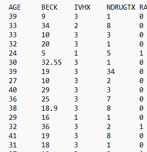

ici c’est un exemple sur un autre fichier de donnée ici c’est le `.`

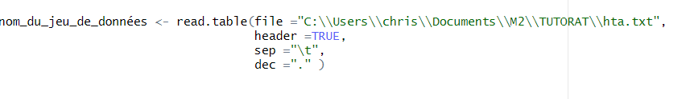

Voilà il ne reste plus qu’a faire `ctrl + entrée` et ton jeu de données est importé.

```r
nom_du_jeu_de_donnees <- read.table(file = "C:\\Users\\chris\\Documents\\M2\\TUTORAT\\hta.txt" ,
                                    header= TRUE,
                                    sep="\t",
                                    dec=".")
```

Vérifie quand même avec `head()` ou `str()`

```r
head(nom_du_jeu_de_donnees)
```

```
    DATENAIS SEXE HTA DIPNIV TOTMED numero      datem couple
1 28/11/1919    2   1      3      4      1 13/07/1999    518
2 07/05/1915    2   1      3      6      2 17/02/1999    433
3 08/02/1927    1   0      3      2      4 19/10/1999    605
4 03/08/1917    2   1      3      9      5 29/04/1999    481
5 09/12/1927    1   1      4      9      7 04/02/2000    187
6 19/10/1925    1   1      3      7      8 30/07/1999    533
```

```r
str(nom_du_jeu_de_donnees)
```

```
'data.frame':   2000 obs. of  8 variables:
 $ DATENAIS: chr  "28/11/1919" "07/05/1915" "08/02/1927" "03/08/1917" ...
 $ SEXE    : int  2 2 1 2 1 1 1 1 1 2 ...
 $ HTA     : int  1 1 0 1 1 1 0 1 1 1 ...
 $ DIPNIV  : int  3 3 3 3 4 3 4 5 4 3 ...
 $ TOTMED  : int  4 6 2 9 9 7 7 13 4 3 ...
 $ numero  : int  1 2 4 5 7 8 9 10 11 14 ...
 $ datem   : chr  "13/07/1999" "17/02/1999" "19/10/1999" "29/04/1999" ...
 $ couple  : int  518 433 605 481 187 533 770 430 763 71 ...
```

Importation ok :)

**Merci d’avoir lu cette page ! J’espère qu’elle vous aura été utile****.**